title: “Principal Component Regression” author: “Grant Bailey, Lizhou Wang” date: “12/8/2020” output: beamer_presentation ##

# Mathematical Theory

## Introduction

Let’s look at some random data. Here we linearly regress $y$ against $x$. I’ve added red lines to show the two directions we have our normally distributed random data going.

```r
set.seed(0)
x <- rnorm(1000, 0, 3)
y <- rnorm(1000, 0, 1)
mod <- lm(y ~ x)
```

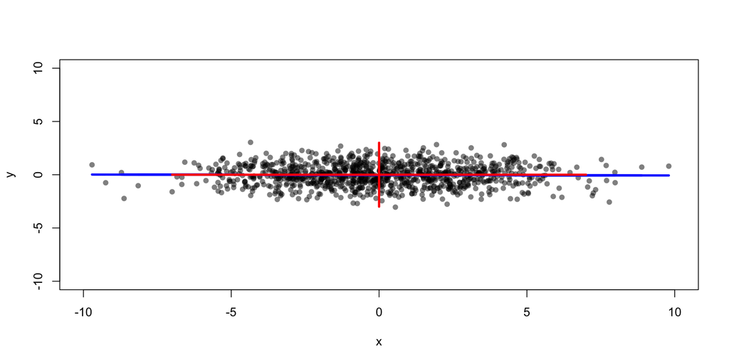

[output not shown]

## Rotation

Now let’s rotate the data and the lines, and fit another regression model with our new dimensions.
$$\begin{align*}
A &=
\begin{bmatrix}
\vec{x} & \vec{y} \\
\end{bmatrix} \\
\theta &= \frac{-\pi}{3} \\
R &=
\begin{bmatrix}
cos(\theta) & -sin(\theta) \\
sin(\theta) & cos(\theta)
\end{bmatrix} \\
B &= AR
\end{align*}$$

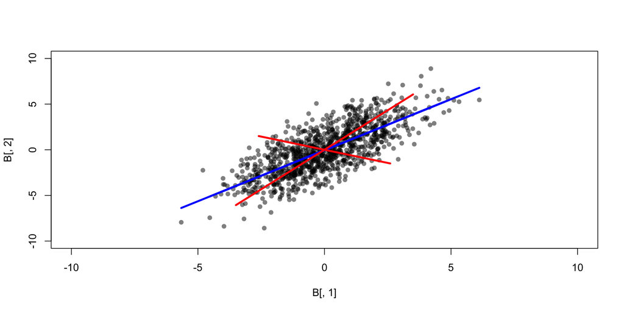

## Principal Components

Principal components are directions that maximize variance in a matrix. They can also be seen as “axes” for the matrix, which can be seen in our plot. Principal components are, then, the same as eigenvectors. Here are the eigenvectors of our matrix $B$ scaled and drawn on our plot.

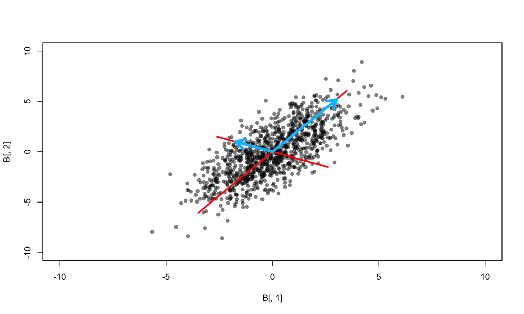

## Mathematical Steps

Linear regression is denoted by the formula $y = X \beta + \epsilon$.

Here are the steps to use our principal components for regression:

1. Normalize both our $X$ and our $y$
2. Obtain singular values and eigenvectors for $X$, where $D$ denotes a diagonal matrix with eigenvalues ordered from greatest to least, and $V$ denotes a matrix with eigenvectors for columns.
3. Reduce the number of columns in $V$ based on the eigenvalues.
4. Let $n$ be the total number of entries (rows), $p$ be the initial number of eigenvalues, and $r$ be the chosen number of eigenvectors to retain. Calculate $Z_{n \times r} = X_{n \times p}V_{p \times r}$
5. Calculate $\beta_Z = (Z^\intercal Z)^{-1} Z^\intercal y$
6. Calculate $\hat{y} = Z \beta_{Z} = X \beta_{X}$, where $\beta_X=V\beta_Z$

## Dimension reduction

One major benefit of principal component regression is its ability to reduce the dimensions of our predictor matrix while retaining as much information as possible, which aids in reducing collinearity. Here are the eigenvalues of a randomly generated $10 \times 10$ matrix.

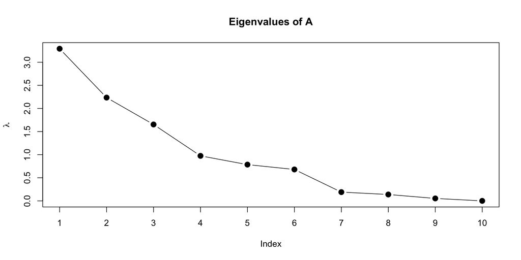

## Dimension Reduction

These eigenvalues reveal how much each eigenvector contributes to the total variance of the matrix. If $\vec{\lambda}$ is the vector of eigenvalues, then $\frac{100}{\sum{\vec{\lambda}}} \vec{\lambda}$ tells us what percentage of the variance is explained by each eigenvalue.

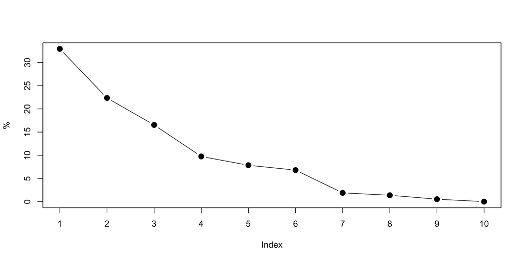

The first eigenvector captures about 33% of variance, while the tenth eigenvector contributes almost nothing. There is a steep drop-off after our sixth eigenvalue, so six eigenvectors might be a good choice for our regression.

## Dimension Reduction

If we cumulatively sum this vector of percentage contributions. using only the first five eigenvectors, we capture 89% of variance. Using the first six eigenvectors, we capture 96% of the variance. After that, the contributions taper off.

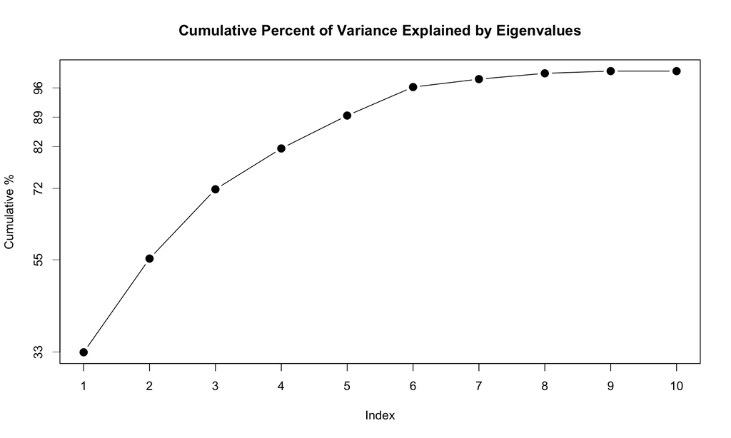

# Example 1

## IMDb Data

Let’s now use principal component regression to forecast IMDB user reviews for movies.

```r
data <- read.csv("IMDb movies.csv")
names(data)
```

```
 [1] "imdb_title_id"         "title"                 "original_title"
 [4] "year"                  "date_published"        "genre"
 [7] "duration"              "country"               "language"
[10] "director"              "writer"                "production_company"
[13] "actors"                "description"           "avg_vote"
[16] "votes"                 "budget"                "usa_gross_income"
[19] "worlwide_gross_income" "metascore"             "reviews_from_users"
[22] "reviews_from_critics"
```

Here we have data from the online movie database service IMDb.. We are using this dataset because we can expect a high degree of collinearity between variables such as `metascore` and `reviews_from_critics`, though this is not always the case.

## Preparing our data

First we need to select the proper variables for this type of analysis. Since principal component regression examines the eigenvalues of a matrix, we’ll stick with numerical data types. Principal component regression can be done with categorical variables, but we’re sticking with the basics here.

```r
revised_data <- data[substr(data$budget, 1, 1) == "$", ]
revised_data$budget <-
  substr(revised_data$budget, 2, stop = 1000) %>% as.numeric
my_data <-
  revised_data[sapply(revised_data, class) %in% c("numeric", "integer")] %>%
  na.omit %>%
  .[c(6, 1:5, 7)] # Reorder our dataframe to put metascore at the front
summary(my_data)
```

```
 reviews_from_users    duration        avg_vote         votes
 Min.   :    1      Min.   : 60.0   Min.   :1.400   Min.   :    106
 1st Qu.:   76      1st Qu.: 94.0   1st Qu.:5.800   1st Qu.:  10287
 Median :  166      Median :104.0   Median :6.500   Median :  35503
 Mean   :  309      Mean   :107.3   Mean   :6.383   Mean   :  92431
 3rd Qu.:  347      3rd Qu.:117.0   3rd Qu.:7.100   3rd Qu.: 101314
 Max.   :10472      Max.   :338.0   Max.   :9.300   Max.   :2278845
     budget            metascore      reviews_from_critics
 Min.   :        1   Min.   :  1.00   Min.   :  1.0
 1st Qu.:  5000000   1st Qu.: 41.00   1st Qu.: 51.0
 Median : 15000000   Median : 54.00   Median :104.0
 Mean   : 29237166   Mean   : 54.06   Mean   :139.5
 3rd Qu.: 35000000   3rd Qu.: 67.00   3rd Qu.:187.0
 Max.   :356000000   Max.   :100.00   Max.   :999.0
```

## Preparing our data

And now we normalize our data columns using the two-norm and center it so that $\mu=0$.

```r
my_data <- my_data %>%
  data.Normalization(type = "n12", normalization = "column")
```

Our data is now scaled and centered, making it ready for principal component regression. Note that we will get differently scaled eigenvalues when we use a different scaling algorithm, but our final results will be the same.

## Principal Components

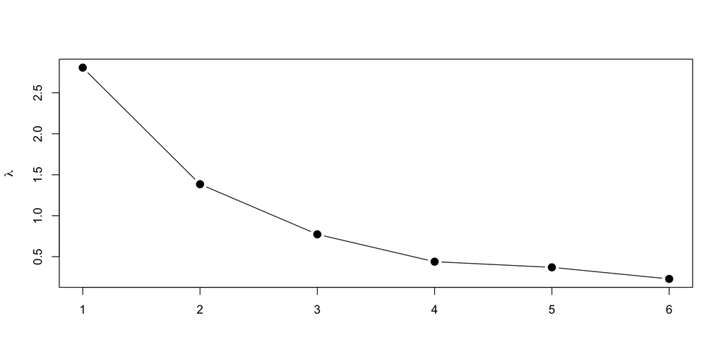

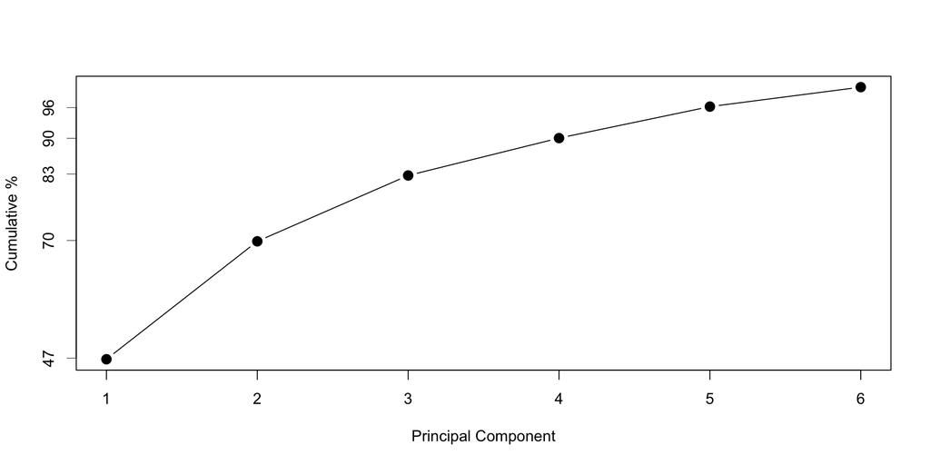

## Full PC Rank Regression

Let’s calculate a regression using all the principal components.

```r
data.V <- data.eig$vectors
data.Z <- data.X %*% data.V
data.Y <- my_data[1] %>% as.matrix # Normalized and scaled metascore
data.model1.z <- lm(data.Y ~ data.Z)
```

```
Call:
lm(formula = data.Y ~ data.Z)

Residuals:
      Min        1Q    Median        3Q       Max
-0.037716 -0.002114 -0.000253  0.001173  0.204991

Coefficients:
              Estimate Std. Error t value Pr(>|t|)
(Intercept) -5.448e-18  9.206e-05   0.000 1.000000
data.Z1     -3.916e-01  4.571e-03 -85.658  < 2e-16 ***
data.Z2     -2.713e-01  6.510e-03 -41.670  < 2e-16 ***
data.Z3     -1.144e-01  8.713e-03 -13.133  < 2e-16 ***
data.Z4     -3.235e-01  1.156e-02 -27.981  < 2e-16 ***
data.Z5      4.440e-02  1.260e-02   3.524 0.000428 ***
data.Z6     -1.575e-01  1.602e-02  -9.832  < 2e-16 ***
---
Signif. codes:  0 '***' 0.001 '**' 0.01 '*' 0.05 '.' 0.1 ' ' 1

Residual standard error: 0.007658 on 6913 degrees of freedom
Multiple R-squared:  0.5946,    Adjusted R-squared:  0.5942
F-statistic:  1690 on 6 and 6913 DF,  p-value: < 2.2e-16
```

In this model, all our principal components are significant, and our $R^2=0.5946$.

## Reduced Principal Components

Now, let’s compare this to our model if we use five principal components, accounting for about $96\%$ of our matrix’s variance. We set our $V$ to just the first five eigenvectors (principal components), then repeat the above steps.

```r
data.V <- data.eig$vectors[,1:5]
```

```
Call:
lm(formula = data.Y ~ data.Z)

Residuals:
      Min        1Q    Median        3Q       Max
-0.036452 -0.002126 -0.000217  0.001301  0.203332

Coefficients:
              Estimate Std. Error t value Pr(>|t|)
(Intercept) -5.096e-18  9.269e-05    0.00 1.000000
data.Z1     -3.916e-01  4.603e-03  -85.07  < 2e-16 ***
data.Z2     -2.713e-01  6.555e-03  -41.38  < 2e-16 ***
data.Z3     -1.144e-01  8.773e-03  -13.04  < 2e-16 ***
data.Z4     -3.235e-01  1.164e-02  -27.79  < 2e-16 ***
data.Z5      4.440e-02  1.269e-02    3.50 0.000468 ***
---
Signif. codes:  0 '***' 0.001 '**' 0.01 '*' 0.05 '.' 0.1 ' ' 1

Residual standard error: 0.007711 on 6914 degrees of freedom
Multiple R-squared:  0.5889,    Adjusted R-squared:  0.5886
F-statistic:  1981 on 5 and 6914 DF,  p-value: < 2.2e-16
```

Again, all of our principal components are significant, and our $R^2=0.5889$. Although we’ve removed predictor variable that was considered significant, the two models have very similar $R^2$ values.

## Further Reducing Principal Components

Now, let’s create a model using four principal components, accounting for $90\%$ of the variance in our data. We set our $V$ to just the first four eigenvectors, then repeat the above steps.

```r
data.V <- data.eig$vectors[,1:4]
```

```
Call:
lm(formula = data.Y ~ data.Z)

Residuals:
      Min        1Q    Median        3Q       Max
-0.037010 -0.002171 -0.000182  0.001341  0.202767

Coefficients:
              Estimate Std. Error t value Pr(>|t|)
(Intercept) -5.288e-18  9.277e-05    0.00        1
data.Z1     -3.916e-01  4.606e-03  -85.00   <2e-16 ***
data.Z2     -2.713e-01  6.560e-03  -41.35   <2e-16 ***
data.Z3     -1.144e-01  8.780e-03  -13.03   <2e-16 ***
data.Z4     -3.235e-01  1.165e-02  -27.77   <2e-16 ***
---
Signif. codes:  0 '***' 0.001 '**' 0.01 '*' 0.05 '.' 0.1 ' ' 1

Residual standard error: 0.007717 on 6915 degrees of freedom
Multiple R-squared:  0.5882,    Adjusted R-squared:  0.5879
F-statistic:  2469 on 4 and 6915 DF,  p-value: < 2.2e-16
```

With just four principal components, we get $R^2=0.5882$, compared to $R^2=0.5889$ for five principal components and $R^2=0.5946$ for all six.

## Compare to Ordinary Least-Squares Regression

Let’s compare our models to an ordinary least-squares regression model.

```r
data.ols1 <- lm(reviews_from_users ~ ., data=my_data)
summary(data.ols1)
```

```
Call:
lm(formula = reviews_from_users ~ ., data = my_data)

Residuals:
      Min        1Q    Median        3Q       Max
-0.037716 -0.002114 -0.000253  0.001173  0.204991

Coefficients:
                       Estimate Std. Error t value Pr(>|t|)
(Intercept)          -8.267e-18  9.206e-05   0.000    1.000
duration              7.540e-02  8.762e-03   8.606  < 2e-16 ***
avg_vote             -5.979e-02  1.248e-02  -4.792 1.68e-06 ***
votes                 5.532e-01  1.062e-02  52.102  < 2e-16 ***
budget                1.096e-01  9.712e-03  11.283  < 2e-16 ***
metascore             6.703e-03  1.166e-02   0.575    0.565
reviews_from_critics  2.100e-01  1.062e-02  19.772  < 2e-16 ***
---
Signif. codes:  0 '***' 0.001 '**' 0.01 '*' 0.05 '.' 0.1 ' ' 1

Residual standard error: 0.007658 on 6913 degrees of freedom
Multiple R-squared:  0.5946,    Adjusted R-squared:  0.5942
F-statistic:  1690 on 6 and 6913 DF,  p-value: < 2.2e-16
```

## Reducing Predictors of our OLS

Say we want to reduce the number of predictor variables in our regression. Since our data is scaled, we can see the contribution of our points by their $\beta$ value.

|  | beta |
| --- | --- |
| (Intercept) | 0.0000 |
| metascore | 0.0067 |
| avg_vote | -0.0598 |
| duration | 0.0754 |
| budget | 0.1096 |
| reviews_from_critics | 0.2100 |
| votes | 0.5532 |

Now let’s compare how dimension reduction affects $R^2$ for ordinary least-squares compared to principal component regression.

## Comparing $R^2$ for OLS and PCR

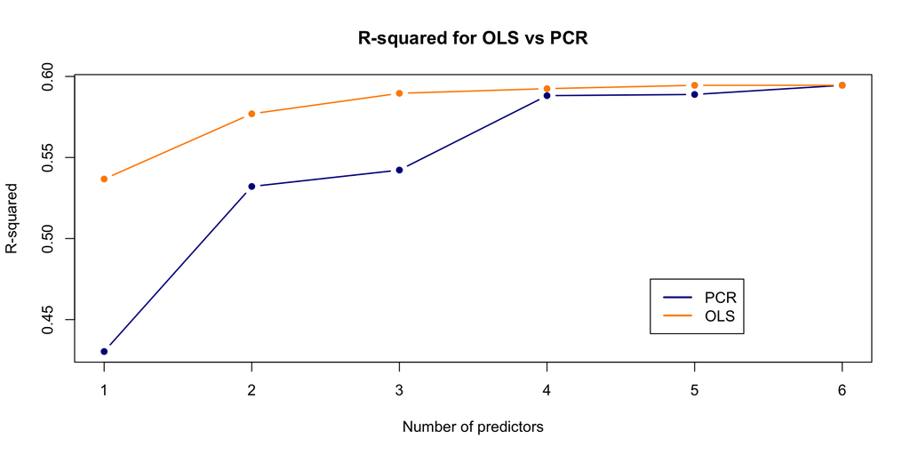

What may be surprising here is that using principal component regression is not helpful in this example! This is because our principal components are just calculated using our predictor variables, and so while our first principal component might maximize variance in our data, it does not necessarily maximize impact on our response variable.

## Why Not PCR

In our example, we assumed that `metascore` and `reviews_from_critics` faced potential collinearity. This turned out not to be the case, however.

```r
vif(data.ols1)
```

```
            duration             avg_vote                votes
            1.309125             2.654144             1.922164
              budget            metascore reviews_from_critics
            1.608350             2.317912             1.923185
```

This indicates low levels of collinearity. We also only had only six predictor columns, and PCR is most effective when there are a large number of columns compared to rows. It can especially be employed when we have more columns than rows!

# Example 2

## Compare to MLR

I will use a small example to show how PCR is better than MLR in some cases

[output not shown]

split dataset into training set and test set

This time let’s analyze how mpg can be affected by all the other factors.

let’s try multiple linear regression first ##

[output not shown]

[output not shown]

now let’s try to do pcr for this dataset

[output not shown]

[output not shown]

From the above we can see that our mse is less for PCR than for MLR

# compare to MLR

I will use a small example to show how PCR is better than MLR in some cases

```r
summary(mtcars)
```

```
      mpg             cyl             disp             hp
 Min.   :10.40   Min.   :4.000   Min.   : 71.1   Min.   : 52.0
 1st Qu.:15.43   1st Qu.:4.000   1st Qu.:120.8   1st Qu.: 96.5
 Median :19.20   Median :6.000   Median :196.3   Median :123.0
 Mean   :20.09   Mean   :6.188   Mean   :230.7   Mean   :146.7
 3rd Qu.:22.80   3rd Qu.:8.000   3rd Qu.:326.0   3rd Qu.:180.0
 Max.   :33.90   Max.   :8.000   Max.   :472.0   Max.   :335.0
      drat             wt             qsec             vs
 Min.   :2.760   Min.   :1.513   Min.   :14.50   Min.   :0.0000
 1st Qu.:3.080   1st Qu.:2.581   1st Qu.:16.89   1st Qu.:0.0000
 Median :3.695   Median :3.325   Median :17.71   Median :0.0000
 Mean   :3.597   Mean   :3.217   Mean   :17.85   Mean   :0.4375
 3rd Qu.:3.920   3rd Qu.:3.610   3rd Qu.:18.90   3rd Qu.:1.0000
 Max.   :4.930   Max.   :5.424   Max.   :22.90   Max.   :1.0000
       am              gear            carb
 Min.   :0.0000   Min.   :3.000   Min.   :1.000
 1st Qu.:0.0000   1st Qu.:3.000   1st Qu.:2.000
 Median :0.0000   Median :4.000   Median :2.000
 Mean   :0.4062   Mean   :3.688   Mean   :2.812
 3rd Qu.:1.0000   3rd Qu.:4.000   3rd Qu.:4.000
 Max.   :1.0000   Max.   :5.000   Max.   :8.000
```

split dataset into training set and test set

```r
smp_size <- floor(0.80 * nrow(mtcars))

## set the seed
set.seed(123)
train_ind <- sample(seq_len(nrow(mtcars)), size = smp_size)

train_set <- mtcars[train_ind, ]
test_set <- mtcars[-train_ind, ]
```

This time let’s analyze how mpg can be affected by all the other factors.

let’s try multiple linear regression first ##

```r
mlr<-lm(mpg~., data = train_set)
summary(mlr)
```

```
Call:
lm(formula = mpg ~ ., data = train_set)

Residuals:
    Min      1Q  Median      3Q     Max
-3.8774 -1.3957 -0.0511  0.8254  4.5637

Coefficients:
            Estimate Std. Error t value Pr(>|t|)
(Intercept) 21.48672   21.70872   0.990   0.3391
cyl         -1.02280    1.35957  -0.752   0.4643
disp         0.02220    0.02531   0.877   0.3952
hp          -0.01921    0.02852  -0.674   0.5114
drat         0.22504    1.89085   0.119   0.9070
wt          -4.60044    2.37145  -1.940   0.0728 .
qsec         0.83809    0.80049   1.047   0.3129
vs           0.76966    2.46407   0.312   0.7594
am           2.38345    2.51892   0.946   0.3601
gear        -0.14113    1.77632  -0.079   0.9378
carb         0.29213    1.01352   0.288   0.7774
---
Signif. codes:  0 '***' 0.001 '**' 0.01 '*' 0.05 '.' 0.1 ' ' 1

Residual standard error: 2.85 on 14 degrees of freedom
Multiple R-squared:  0.8854,    Adjusted R-squared:  0.8035
F-statistic: 10.82 on 10 and 14 DF,  p-value: 5.62e-05
```

```r
mlr_pred<-predict(mlr,test_set)
mean((mlr_pred-test_set$mpg)^2)
```

```
[1] 6.70686
```

now let’s try to do pcr for this dataset

```r
library(pls)
pcr<-pcr(mpg~., data = train_set, scale = TRUE, validation = "CV")
summary(pcr)
```

```
Data:   X dimension: 25 10
    Y dimension: 25 1
Fit method: svdpc
Number of components considered: 10

VALIDATION: RMSEP
Cross-validated using 10 random segments.
       (Intercept)  1 comps  2 comps  3 comps  4 comps  5 comps  6 comps
CV           6.562    2.811    2.865    2.704    2.767    2.803    2.918
adjCV        6.562    2.791    2.842    2.680    2.742    2.773    2.883
       7 comps  8 comps  9 comps  10 comps
CV       3.030    3.169    3.730     4.149
adjCV    2.991    3.115    3.635     4.020

TRAINING: % variance explained
     1 comps  2 comps  3 comps  4 comps  5 comps  6 comps  7 comps  8 comps
X      58.45    83.42    89.97    92.98    95.10    97.12    98.54    99.37
mpg    84.57    84.58    86.57    86.66    86.78    86.81    86.82    87.28
     9 comps  10 comps
X      99.81    100.00
mpg    87.29     88.54
```

[output not shown]

## Sources

- https://rpubs.com/esobolewska/pcr-step-by-step
- https://en.wikipedia.org/wiki/Principal_component_regression
- https://blogs.sas.com/content/iml/2017/10/25/principal-component-regression-drawbacks.html